# Exercise 1

Jaymeee3

1. Import the dataset movies.csv (Note: the separator is a comma).

```r
mv <- read.table("movies.csv", header=T, sep=",")
```

2. Check that the nature of the imported variables has been correctly identified. If necessary, convert the variables to the appropriate format. Bonus: exclude the variables X and overview.

```r
str(mv)
```

```
## 'data.frame':    8560 obs. of  8 variables:
##  $ X           : int  1 2 3 4 5 6 7 8 9 10 ...
##  $ id          : int  278 19404 238 424 240 667257 372754 129 372058 696374 ...
##  $ title       : chr  "The Shawshank Redemption" "Dilwale Dulhania Le Jayenge" "The Godfather" "Schindler's List" ...
##  $ overview    : chr  "Framed in the 1940s for the double murder of his wife and her lover, upstanding banker Andy Dufresne begins a n"| __truncated__ "Raj is a rich, carefree, happy-go-lucky second generation NRI. Simran is the daughter of Chaudhary Baldev Singh"| __truncated__ "Spanning the yea…
##  $ release_year: int  1994 1995 1972 1993 1974 2021 2016 2001 2016 2020 ...
##  $ popularity  : num  62.6 19.1 57.7 41.1 46.7 ...
##  $ vote_average: num  8.7 8.7 8.7 8.6 8.6 8.6 8.6 8.5 8.5 8.5 ...
##  $ vote_count  : int  21456 3652 15990 12778 9640 237 230 12848 8708 2245 ...
```

```r
#Proceeding with variable type casting
library("tidyverse") #to access pipeline construction and the mutate verb
mv <- mv %>% select(-X,-overview) %>% mutate(id=as.numeric(id),
              title=as.factor(title),
              release_year=as.numeric(release_year),
              vote_count=as.numeric(vote_count))
```

3. Create a new categorical variable (name: year_cat) with the following levels: pre-2000, 2000–2010, post-2010, based on the variable release_year. Ensure the new variable has the correct data type.

```r
unique(mv$release_year)
```

```
##   [1] 1994 1995 1972 1993 1974 2021 2016 2001 2020 2022 2019 1957 1999 2008 2003
##  [16] 1966 1988 1954 1990 1997 2000 1984 1962 1960 1975 2018 2002 2013 2004 2011
##  [31] 1980 1950 2014 1998 1963 1931 1952 1940 2010 1985 1991 1936 1989 1968 1953
##  [46] 1964 1979 1948 2012 1946 1921 1970 2017 1945 1971 1958 2009 1977 2006 1927
##  [61] 1976 1961 1942 1983 1959 1924 1944 1992 1987 1955 1956 2007 1996 1965 2015
##  [76] 2005 1928 1981 1949 1973 1926 1978 1941 1982 1925 1939 1986 1969 1902 1920
##  [91] 1951 1934 1947 1923 1967 1943 1937 1932 1930 1922 1938 1933 1935 1929 1918
## [106] 1917 1916 1903 1915
```

```r
#The case when function will be used to recode the variable and group its values into classes

mv <- mv %>% mutate(year_cat= case_when(release_year< 2000 ~ "Pre anni 2000",
                                        release_year>=2000 & release_year<=2010 ~ "2000-2010",
                                        release_year>2010 ~ "Post 2010")) %>%
                      mutate(year_cat=factor(year_cat, levels = c("Pre anni 2000", "2000-2010", "Post 2010", ordered=T)))

#I use a table to check the new variable
table(mv$year_cat)
```

```
##
## Pre anni 2000     2000-2010     Post 2010          TRUE
##          2674          2244          3642             0
```

4. Graphically represent the new variable and provide commentary.

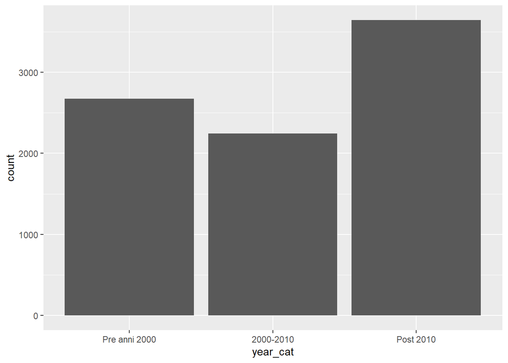

```r
#For the graphical visualization of variables, I will use ggplot(). The choice of visualization also depends on the nature of the variable, which in this case is a factor, so I will use geom_bar().
mv %>% ggplot(aes(x=year_cat)) + geom_bar()
```

5. Create a dataset containing only movies that received more than 500 reviews (vote_count) and sort it based on the score received (vote_count).

```r
#After using filter to select movies with more than 500 reviews, I proceed with sorting using arrange(), which allows me to view the data in ascending order based on the vote_count variable.

mv1 <- mv %>% filter(vote_count>500) %>% arrange(vote_count)
```

6. Analyze the number of votes received by movies based on their year of release. Graphically represent the relationship between the numerical variables release_year and vote_count. Does any kind of relationship emerge? Comment.

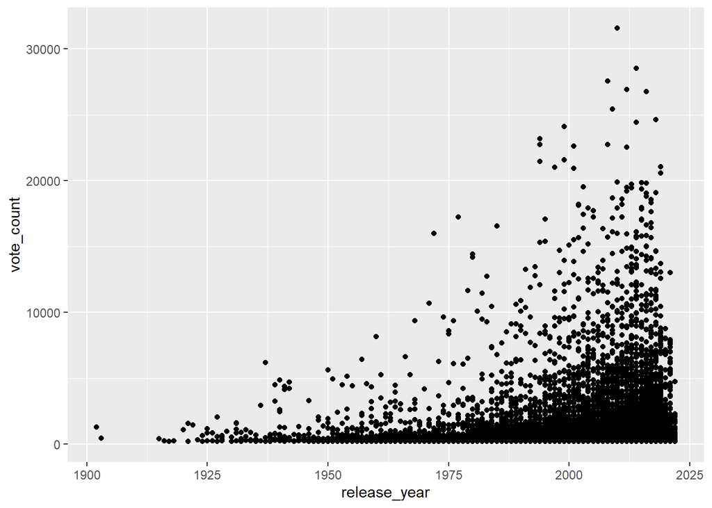

```r
#In this case, the required graphical analysis is a bivariate analysis, and since both variables are numerical, a scatter plot (geom_point()) will be used.

mv %>% ggplot(aes(x=release_year, y=vote_count)) + geom_point()
```